# GSSPS-ESLS - Social Network Analysis

Hands-on sessions

Federico Bianchi

# 1 Introduction

- This is a notebook for hands-on sessions of the Social Network Analysis course for Ph.D. students of the Graduate School of Social and Political Sciences, University of Milan (Italy).
- Analysed data are taken from Bianchi, Casnici, and Squazzoni (2018)

# 2 Collaboration

## 2.1 Loading data

- Now, we need to import data on *collaboration* relationships.
- In order to let `R` find the data, we need to move the data file to the same directory where our Rstudio project is located (i.e., the *working directory*)

If you don’t remember what working directory you’re in:

```r
getwd()
```

```
## [1] "/Users/federico/Documents/sna-nasp/analysis"
```

- Let’s inspect the data structure: we could either open the file outside Rstudio or even from within
- It’s a .txt file. What do you see?
- It’s an **adjacency matrix** (see [slides](https://federico-bianchi.github.io/teaching/))
- Values are 0 and 1 and are separated by a tab (`\t`)
- In order to load it, we need a function to read a table data structure.
- `read.table` is classic R, while `readr::read_delim` is faster. Let’s load the `readr` package, included in the `tidyverse`.

```r
# library(tidyverse)
library(readr)
```

Now we can inspect the `read_delim` function in the console, by hitting `?read_delim`

```r
?read_delim
```

What information do we need? * the file name: `collaboration.txt` * the column separator: `"\t"` * whether we have column names: no

Where is my data file?

```r
dir()
```

```
##  [1] "%"                     "01.nb.html"            "01.Rmd"
##  [4] "analysis.Rproj"        "data"                  "hands-on_files"
##  [7] "hands-on-teacher.html" "hands-on-teacher.Rmd"  "hands-on.Rmd"
## [10] "references.bib"
```

In order to maximise reproducibility, we need the path to be available to all possible colleagues. We can use the `here::here` function, which builds a new path regardless of the original path. Let’s load the `here` package.

```r
library(here)
```

The function `here()` finds my working directory and builds a plausible path towards the specified arguments.

```r
here("data", "collaboration.txt")
```

```
## [1] "/Users/federico/Documents/sna-nasp/analysis/data/collaboration.txt"
```

Now we’re ready to load collaboration data as a new object. We can use `read_tsv`, which takes `"\t"` as a default value of the `delim` parameter

```r
collab.dat <- read_tsv(file = here("data", "collaboration.txt"), col_names = FALSE)
collab.dat
```

| X1 | X2 | X3 | X4 | X5 | X6 | X7 | X8 | X9 | X10 | X11 | X12 | X13 | X14 | X15 | X16 | X17 | X18 | X19 | X20 | X21 | X22 | X23 | X24 | X25 | X26 | X27 | X28 | X29 |
| --- | --- | --- | --- | --- | --- | --- | --- | --- | --- | --- | --- | --- | --- | --- | --- | --- | --- | --- | --- | --- | --- | --- | --- | --- | --- | --- | --- | --- |
| 0 | 0 | 0 | 0 | 0 | 0 | 0 | 0 | 0 | 0 | 0 | 1 | 0 | 0 | 0 | 0 | 0 | 0 | 0 | 0 | 0 | 0 | 0 | 0 | 0 | 0 | 0 | 0 | 0 |
| 0 | 0 | 0 | 1 | 0 | 0 | 1 | 1 | 1 | 1 | 0 | 0 | 1 | 1 | 1 | 1 | 0 | 0 | 0 | 0 | 0 | 0 | 0 | 0 | 0 | 0 | 0 | 0 | 0 |
| 0 | 0 | 0 | 0 | 0 | 1 | 0 | 1 | 1 | 1 | 0 | 0 | 0 | 1 | 0 | 0 | 0 | 0 | 1 | 1 | 0 | 0 | 1 | 0 | 1 | 1 | 1 | 1 | 0 |
| 0 | 1 | 0 | 0 | 0 | 0 | 0 | 0 | 1 | 1 | 0 | 0 | 0 | 1 | 0 | 0 | 0 | 0 | 0 | 0 | 0 | 0 | 0 | 0 | 0 | 0 | 0 | 0 | 0 |
| 0 | 0 | 0 | 0 | 0 | 0 | 0 | 0 | 0 | 0 | 0 | 0 | 0 | 0 | 0 | 0 | 0 | 0 | 0 | 0 | 0 | 0 | 0 | 0 | 0 | 0 | 0 | 0 | 0 |
| 0 | 0 | 1 | 0 | 0 | 0 | 0 | 0 | 1 | 1 | 0 | 0 | 1 | 0 | 1 | 1 | 1 | 0 | 1 | 1 | 0 | 0 | 1 | 0 | 0 | 0 | 0 | 0 | 0 |
| 0 | 1 | 0 | 0 | 0 | 0 | 0 | 0 | 0 | 0 | 0 | 0 | 0 | 0 | 0 | 0 | 0 | 0 | 0 | 0 | 1 | 0 | 0 | 0 | 0 | 0 | 0 | 0 | 0 |
| 0 | 1 | 1 | 0 | 0 | 0 | 0 | 0 | 0 | 1 | 0 | 0 | 0 | 0 | 0 | 0 | 0 | 0 | 1 | 0 | 1 | 0 | 0 | 0 | 0 | 0 | 1 | 1 | 0 |
| 0 | 1 | 1 | 1 | 0 | 1 | 0 | 0 | 0 | 0 | 0 | 0 | 0 | 1 | 0 | 0 | 0 | 0 | 1 | 1 | 0 | 0 | 1 | 0 | 0 | 0 | 0 | 0 | 0 |
| 0 | 1 | 1 | 1 | 0 | 1 | 0 | 1 | 0 | 0 | 0 | 0 | 1 | 0 | 1 | 1 | 0 | 0 | 1 | 1 | 1 | 0 | 1 | 0 | 0 | 1 | 1 | 1 | 0 |

[output cut: 19 more lines]

What kind of object have we stored our data in?

```r
class(collab.dat)
```

```
## [1] "spec_tbl_df" "tbl_df"      "tbl"         "data.frame"
```

It’s a `tibble`, the `tidyverse` version of a `data.frame`.

Let’s inspect our data

```r
str(collab.dat)
```

```
## spec_tbl_df[,29] [29 × 29] (S3: spec_tbl_df/tbl_df/tbl/data.frame)
##  $ X1 : num [1:29] 0 0 0 0 0 0 0 0 0 0 ...
##  $ X2 : num [1:29] 0 0 0 1 0 0 1 1 1 1 ...
##  $ X3 : num [1:29] 0 0 0 0 0 1 0 1 1 1 ...
##  $ X4 : num [1:29] 0 1 0 0 0 0 0 0 1 1 ...
##  $ X5 : num [1:29] 0 0 0 0 0 0 0 0 0 0 ...
##  $ X6 : num [1:29] 0 0 1 0 0 0 0 0 1 1 ...
##  $ X7 : num [1:29] 0 1 0 0 0 0 0 0 0 0 ...
##  $ X8 : num [1:29] 0 1 1 0 0 0 0 0 0 1 ...
##  $ X9 : num [1:29] 0 1 1 1 0 1 0 0 0 0 ...
##  $ X10: num [1:29] 0 1 1 1 0 1 0 1 0 0 ...
##  $ X11: num [1:29] 0 0 0 0 0 0 0 0 0 0 ...
##  $ X12: num [1:29] 1 0 0 0 0 0 0 0 0 0 ...
##  $ X13: num [1:29] 0 1 0 0 0 1 0 0 0 1 ...
##  $ X14: num [1:29] 0 1 1 1 0 0 0 0 1 0 ...
##  $ X15: num [1:29] 0 1 0 0 0 1 0 0 0 1 ...
##  $ X16: num [1:29] 0 1 0 0 0 1 0 0 0 1 ...
##  $ X17: num [1:29] 0 0 0 0 0 1 0 0 0 0 ...
##  $ X18: num [1:29] 0 0 0 0 0 0 0 0 0 0 ...
##  $ X19: num [1:29] 0 0 1 0 0 1 0 1 1 1 ...
##  $ X20: num [1:29] 0 0 1 0 0 1 0 0 1 1 ...
##  $ X21: num [1:29] 0 0 0 0 0 0 1 1 0 1 ...
##  $ X22: num [1:29] 0 0 0 0 0 0 0 0 0 0 ...
##  $ X23: num [1:29] 0 0 1 0 0 1 0 0 1 1 ...
##  $ X24: num [1:29] 0 0 0 0 0 0 0 0 0 0 ...
##  $ X25: num [1:29] 0 0 1 0 0 0 0 0 0 0 ...
##  $ X26: num [1:29] 0 0 1 0 0 0 0 0 0 1 ...
##  $ X27: num [1:29] 0 0 1 0 0 0 0 1 0 1 ...
##  $ X28: num [1:29] 0 0 1 0 0 0 0 1 0 1 ...
##  $ X29: num [1:29] 0 0 0 0 0 0 0 0 0 0 ...
##  - attr(*, "spec")=
##   .. cols(
##   ..   X1 = col_double(),
##   ..   X2 = col_double(),
##   ..   X3 = col_double(),
##   ..   X4 = col_double(),
##   ..   X5 = col_double(),
##   ..   X6 = col_double(),
##   ..   X7 = col_double(),
##   ..   X8 = col_double(),
##   ..   X9 = col_double(),
##   ..   X10 = col_double(),
##   ..   X11 = col_double(),
##   ..   X12 = col_double(),
##   ..   X13 = col_double(),
##   ..   X14 = col_double(),
##   ..   X15 = col_double(),
##   ..   X16 = col_double(),
##   ..   X17 = col_double(),
##   ..   X18 = col_double(),
##   ..   X19 = col_double(),
##   ..   X20 = col_double(),
##   ..   X21 = col_double(),
##   ..   X22 = col_double(),
##   ..   X23 = col_double(),
##   ..   X24 = col_double(),
##   ..   X25 = col_double(),
##   ..   X26 = col_double(),
##   ..   X27 = col_double(),
##   ..   X28 = col_double(),
##   ..   X29 = col_double()
##   .. )
```

- It’s interpreted as a case-by-variable matrix, with 29 variables.
- Instead, what we need is an adjacency matrix.

```r
collab.dat <- as.matrix(collab.dat)
collab.dat
```

```
##       X1 X2 X3 X4 X5 X6 X7 X8 X9 X10 X11 X12 X13 X14 X15 X16 X17 X18 X19 X20
##  [1,]  0  0  0  0  0  0  0  0  0   0   0   1   0   0   0   0   0   0   0   0
##  [2,]  0  0  0  1  0  0  1  1  1   1   0   0   1   1   1   1   0   0   0   0
##  [3,]  0  0  0  0  0  1  0  1  1   1   0   0   0   1   0   0   0   0   1   1
##  [4,]  0  1  0  0  0  0  0  0  1   1   0   0   0   1   0   0   0   0   0   0
##  [5,]  0  0  0  0  0  0  0  0  0   0   0   0   0   0   0   0   0   0   0   0
##  [6,]  0  0  1  0  0  0  0  0  1   1   0   0   1   0   1   1   1   0   1   1
##  [7,]  0  1  0  0  0  0  0  0  0   0   0   0   0   0   0   0   0   0   0   0
##  [8,]  0  1  1  0  0  0  0  0  0   1   0   0   0   0   0   0   0   0   1   0
##  [9,]  0  1  1  1  0  1  0  0  0   0   0   0   0   1   0   0   0   0   1   1
## [10,]  0  1  1  1  0  1  0  1  0   0   0   0   1   0   1   1   0   0   1   1
## [11,]  0  0  0  0  0  0  0  0  0   0   0   0   0   0   0   0   0   0   0   0
## [12,]  1  0  0  0  0  0  0  0  0   0   0   0   0   0   0   0   0   0   0   0
## [13,]  0  1  0  0  0  1  0  0  0   1   0   0   0   0   1   1   0   0   0   1
## [14,]  0  1  1  1  0  0  0  0  1   0   0   0   0   0   0   0   0   0   0   0
```

[output cut: 45 more lines]

Now our data are interpreted by `R` as a matrix.

```r
class(collab.dat)
```

```
## [1] "matrix" "array"
```

## 2.2 From data to graphs

In order to apply some of SNA functions, we need to use the `igraph` package, which handles our data as `igraph` objects, to which its functions can be applied

First, we need to load the package

```r
library(igraph)
```

Now, we have to turn our data into an `igraph` object. There’s a series of primitives starting with `graph_from` that can be useful for us:

```r
collaboration <- graph_from_adjacency_matrix(adjmatrix = collab.dat, mode = "undirected")
collaboration
```

```
## IGRAPH aa3303f UN-- 29 82 --
## + attr: name (v/c)
## + edges from aa3303f (vertex names):
##  [1] X1 --X12 X2 --X4  X2 --X7  X2 --X8  X2 --X9  X2 --X10 X2 --X13 X2 --X14
##  [9] X2 --X15 X2 --X16 X3 --X6  X3 --X8  X3 --X9  X3 --X10 X3 --X14 X3 --X19
## [17] X3 --X20 X3 --X23 X3 --X25 X3 --X26 X3 --X27 X3 --X28 X4 --X9  X4 --X10
## [25] X4 --X14 X6 --X9  X6 --X10 X6 --X13 X6 --X15 X6 --X16 X6 --X17 X6 --X19
## [33] X6 --X20 X6 --X23 X7 --X21 X8 --X10 X8 --X19 X8 --X21 X8 --X27 X8 --X28
## [41] X9 --X14 X9 --X19 X9 --X20 X9 --X23 X10--X13 X10--X15 X10--X16 X10--X19
## [49] X10--X20 X10--X21 X10--X23 X10--X26 X10--X27 X10--X28 X13--X15 X13--X16
## [57] X13--X20 X13--X22 X13--X23 X15--X16 X15--X20 X15--X22 X15--X23 X16--X20
## + ... omitted several edges
```

The summary shows us: * that the network is undirected (UN) * 29 nodes * 82 links * the list of the edges

An `igraph` object is a complex R object made of lists

```r
str(collaboration)
```

```
## List of 10
##  $ :List of 1
##   ..$ X1: 'igraph.vs' Named int 12
##   .. ..- attr(*, "names")= chr "X12"
##   .. ..- attr(*, "env")=<weakref>
##   .. ..- attr(*, "graph")= chr "aa3303f0-1cf1-4bc9-a05b-9c6ab09fe15b"
##  $ :List of 1
##   ..$ X2: 'igraph.vs' Named int [1:9] 4 7 8 9 10 13 14 15 16
##   .. ..- attr(*, "names")= chr [1:9] "X4" "X7" "X8" "X9" ...
##   .. ..- attr(*, "env")=<weakref>
##   .. ..- attr(*, "graph")= chr "aa3303f0-1cf1-4bc9-a05b-9c6ab09fe15b"
##  $ :List of 1
##   ..$ X3: 'igraph.vs' Named int [1:12] 6 8 9 10 14 19 20 23 25 26 ...
##   .. ..- attr(*, "names")= chr [1:12] "X6" "X8" "X9" "X10" ...
##   .. ..- attr(*, "env")=<weakref>
##   .. ..- attr(*, "graph")= chr "aa3303f0-1cf1-4bc9-a05b-9c6ab09fe15b"
##  $ :List of 1
##   ..$ X4: 'igraph.vs' Named int [1:4] 2 9 10 14
##   .. ..- attr(*, "names")= chr [1:4] "X2" "X9" "X10" "X14"
##   .. ..- attr(*, "env")=<weakref>
##   .. ..- attr(*, "graph")= chr "aa3303f0-1cf1-4bc9-a05b-9c6ab09fe15b"
##  $ :List of 1
##   ..$ X5: 'igraph.vs' Named int(0)
##   .. ..- attr(*, "names")= chr(0)
##   .. ..- attr(*, "env")=<weakref>
##   .. ..- attr(*, "graph")= chr "aa3303f0-1cf1-4bc9-a05b-9c6ab09fe15b"
##  $ :List of 1
##   ..$ X6: 'igraph.vs' Named int [1:10] 3 9 10 13 15 16 17 19 20 23
##   .. ..- attr(*, "names")= chr [1:10] "X3" "X9" "X10" "X13" ...
##   .. ..- attr(*, "env")=<weakref>
##   .. ..- attr(*, "graph")= chr "aa3303f0-1cf1-4bc9-a05b-9c6ab09fe15b"
##  $ :List of 1
##   ..$ X7: 'igraph.vs' Named int [1:2] 2 21
##   .. ..- attr(*, "names")= chr [1:2] "X2" "X21"
##   .. ..- attr(*, "env")=<weakref>
##   .. ..- attr(*, "graph")= chr "aa3303f0-1cf1-4bc9-a05b-9c6ab09fe15b"
##  $ :List of 1
##   ..$ X8: 'igraph.vs' Named int [1:7] 2 3 10 19 21 27 28
##   .. ..- attr(*, "names")= chr [1:7] "X2" "X3" "X10" "X19" ...
##   .. ..- attr(*, "env")=<weakref>
##   .. ..- attr(*, "graph")= chr "aa3303f0-1cf1-4bc9-a05b-9c6ab09fe15b"
##  $ :List of 1
##   ..$ X9: 'igraph.vs' Named int [1:8] 2 3 4 6 14 19 20 23
##   .. ..- attr(*, "names")= chr [1:8] "X2" "X3" "X4" "X6" ...
##   .. ..- attr(*, "env")=<weakref>
##   .. ..- attr(*, "graph")= chr "aa3303f0-1cf1-4bc9-a05b-9c6ab09fe15b"
##  $ :List of 1
##   ..$ X10: 'igraph.vs' Named int [1:15] 2 3 4 6 8 13 15 16 19 20 ...
##   .. ..- attr(*, "names")= chr [1:15] "X2" "X3" "X4" "X6" ...
##   .. ..- attr(*, "env")=<weakref>
##   .. ..- attr(*, "graph")= chr "aa3303f0-1cf1-4bc9-a05b-9c6ab09fe15b"
##  - attr(*, "class")= chr "igraph"
```

## 2.3 Visualization

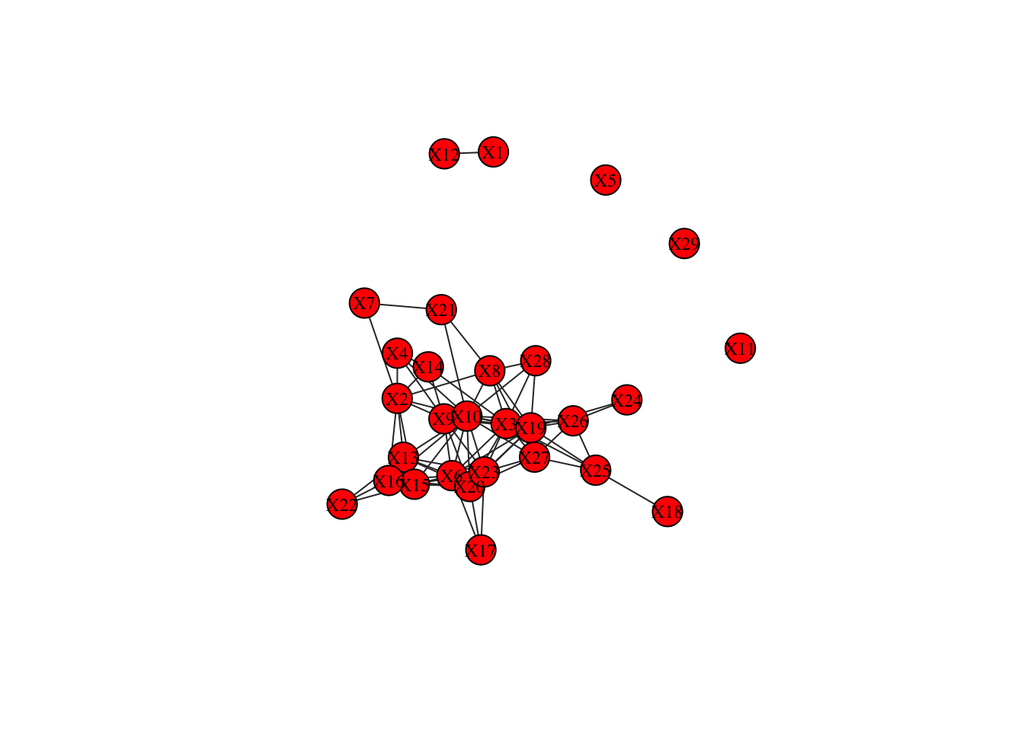

```r
plot(collaboration,
     vertex.color = "red", # changes colour of the nodes
     vertex.label.color = "black", # changes colour of the labels
     vertex.label.cex = .75, # change size of labels to 75% of original size
     # edge.curved=.25, # add a 25% curve to the edges
     edge.color="grey20") # change edge color to grey
```

- Since our data are anonymised, we don’t really need labels
- We can also experiment with different layouts
- We can display curved edges

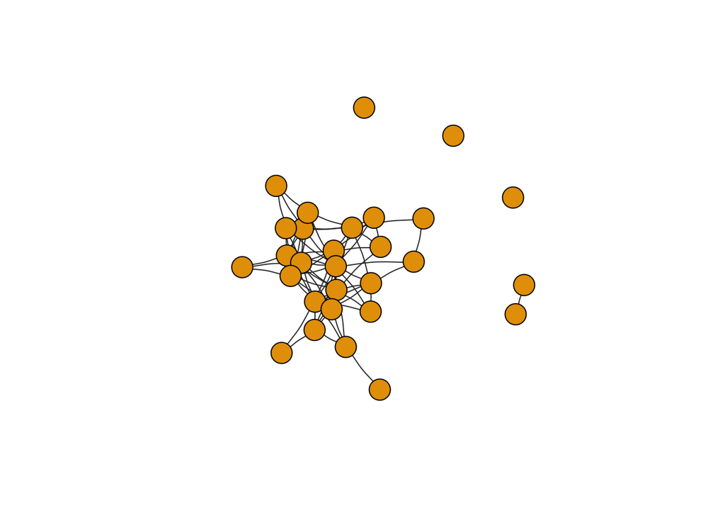

```r
plot(collaboration,
     vertex.label="",
     edge.curved = .1,
     edge.color = "grey20",
     layout = layout_with_fr
     # layout = layout_randomly,
     # layout = layout_in_circle,
     # layout = layout_with_kk,
     # layout = layout_with_graphopt
     )
```

## 2.4 Connectivity

A basic network property we could be interested in is: * how *connected* a network is (*graph-level*) * how (heterogeneously) *connected* nodes are (*node-level*)

Let’s start from the number of edges

```r
ecount(collaboration)
```

```
## [1] 82
```

We can also retrieve the whole list of edges

```r
E(collaboration)
```

```
## + 82/82 edges from aa3303f (vertex names):
##  [1] X1 --X12 X2 --X4  X2 --X7  X2 --X8  X2 --X9  X2 --X10 X2 --X13 X2 --X14
##  [9] X2 --X15 X2 --X16 X3 --X6  X3 --X8  X3 --X9  X3 --X10 X3 --X14 X3 --X19
## [17] X3 --X20 X3 --X23 X3 --X25 X3 --X26 X3 --X27 X3 --X28 X4 --X9  X4 --X10
## [25] X4 --X14 X6 --X9  X6 --X10 X6 --X13 X6 --X15 X6 --X16 X6 --X17 X6 --X19
## [33] X6 --X20 X6 --X23 X7 --X21 X8 --X10 X8 --X19 X8 --X21 X8 --X27 X8 --X28
## [41] X9 --X14 X9 --X19 X9 --X20 X9 --X23 X10--X13 X10--X15 X10--X16 X10--X19
## [49] X10--X20 X10--X21 X10--X23 X10--X26 X10--X27 X10--X28 X13--X15 X13--X16
## [57] X13--X20 X13--X22 X13--X23 X15--X16 X15--X20 X15--X22 X15--X23 X16--X20
## [65] X16--X22 X17--X20 X17--X23 X18--X25 X19--X20 X19--X23 X19--X24 X19--X25
## [73] X19--X26 X19--X27 X19--X28 X20--X23 X20--X27 X23--X27 X24--X26 X25--X26
## + ... omitted several edges
```

The number of edges depends on the number of vertices

```r
vcount(collaboration)
```

```
## [1] 29
```

We can also retrieve the list of vertices

```r
V(collaboration)
```

```
## + 29/29 vertices, named, from aa3303f:
##  [1] X1  X2  X3  X4  X5  X6  X7  X8  X9  X10 X11 X12 X13 X14 X15 X16 X17 X18 X19
## [20] X20 X21 X22 X23 X24 X25 X26 X27 X28 X29
```

### 2.4.1 Density

- In order to infer the level of *connectivity* from the number of edges, we need to compare it to the theoretically maximum value of possible links
- We combine each vertex with all other possible vertices
- Since our network is undirected, we divide by 2, so that we don’t count pairs twice
- We’ll store the calculation output in a new object because we’re going to use it later again and we want to stay [D.R.Y.](https://en.wikipedia.org/wiki/Don%27t_repeat_yourself)

```r
max.links <- vcount(collaboration) * (vcount(collaboration) - 1) / 2
```

- Now, we can calculate *density* as the ratio between the number of actual links and the number of possible links.

```r
density <- ecount(collaboration) / max.links
```

- Actually, we don’t need to perform this calculation every time. There is a specific function in `igraph`

```r
graph.density(collaboration)
```

```
## [1] 0.2019704
```

### 2.4.2 Discussion

- Is the density value high or low? Is our collaboration network *dense* or *sparse*?
- Let’s compare with another network.

# 3 Support

## 3.1 Loading data

- Data on support relationships are stored with a different structure
- It’s an **edgelist** (see [slides](https://federico-bianchi.github.io/teaching/))
- We still need to assign data to a matrix object (not an adjacency matrix, though)

```r
sup.dat <- as.matrix(read_delim(here("data", "support.csv"), delim = " ", col_names = FALSE))
sup.dat
```

```
##        X1    X2
##   [1,] "V1"  "V29"
##   [2,] "V2"  "V4"
##   [3,] "V2"  "V14"
##   [4,] "V2"  "V15"
##   [5,] "V2"  "V28"
##   [6,] "V3"  "V10"
##   [7,] "V3"  "V13"
##   [8,] "V3"  "V15"
##   [9,] "V3"  "V16"
##  [10,] "V3"  "V25"
##  [11,] "V3"  "V26"
##  [12,] "V3"  "V27"
##  [13,] "V4"  "V2"
##  [14,] "V5"  "V24"
```

[output cut: 85 more lines]

## 3.2 From data to graph

```r
support <- graph_from_edgelist(sup.dat)
support
```

```
## IGRAPH 2dc0f45 DN-- 28 99 --
## + attr: name (v/c)
## + edges from 2dc0f45 (vertex names):
##  [1] V1 ->V29 V2 ->V4  V2 ->V14 V2 ->V15 V2 ->V28 V3 ->V10 V3 ->V13 V3 ->V15
##  [9] V3 ->V16 V3 ->V25 V3 ->V26 V3 ->V27 V4 ->V2  V5 ->V24 V6 ->V12 V6 ->V13
## [17] V6 ->V15 V6 ->V16 V6 ->V17 V6 ->V20 V6 ->V23 V7 ->V1  V7 ->V12 V8 ->V2
## [25] V8 ->V4  V8 ->V10 V8 ->V13 V8 ->V15 V8 ->V25 V8 ->V27 V8 ->V28 V9 ->V2
## [33] V9 ->V14 V10->V3  V10->V13 V10->V15 V10->V19 V10->V27 V12->V1  V12->V2
## [41] V12->V10 V12->V20 V13->V16 V14->V2  V14->V8  V14->V9  V14->V25 V15->V6
## [49] V15->V10 V15->V13 V15->V16 V15->V22 V16->V13 V16->V15 V16->V22 V17->V6
## [57] V17->V20 V18->V25 V19->V3  V19->V25 V19->V27 V20->V6  V20->V12 V20->V17
## + ... omitted several edges
```

- Why are nodes 28? We were expecting 29
- One of the nodes might be an *isolate*
- It’s always good practice to store the list of edges and the list of nodes in two different objects, then integrate them in a graph object
- The nodes are coded in the edge list file as “V1,” “V2,” …, “V29”
- So, we’ll generate a character vector by combining “V” with numbers between 1-29

```r
sup.edges <- sup.dat
sup.nodes <- paste0("V", 1:29)
sup.nodes
```

```
##  [1] "V1"  "V2"  "V3"  "V4"  "V5"  "V6"  "V7"  "V8"  "V9"  "V10" "V11" "V12"
## [13] "V13" "V14" "V15" "V16" "V17" "V18" "V19" "V20" "V21" "V22" "V23" "V24"
## [25] "V25" "V26" "V27" "V28" "V29"
```

Now we have a vector of nodes (node list) and a `matrix` of edges (edge list). We can then generate a graph object in a safer way through `graph_from_data_frame`, which takes a node list (vector) and and edge list (matrix) as inputs.

```r
support <- graph_from_data_frame(d = sup.edges, vertices = sup.nodes)
support
```

```
## IGRAPH 721c703 DN-- 29 99 --
## + attr: name (v/c)
## + edges from 721c703 (vertex names):
##  [1] V1 ->V29 V2 ->V4  V2 ->V14 V2 ->V15 V2 ->V28 V3 ->V10 V3 ->V13 V3 ->V15
##  [9] V3 ->V16 V3 ->V25 V3 ->V26 V3 ->V27 V4 ->V2  V5 ->V24 V6 ->V12 V6 ->V13
## [17] V6 ->V15 V6 ->V16 V6 ->V17 V6 ->V20 V6 ->V23 V7 ->V1  V7 ->V12 V8 ->V2
## [25] V8 ->V4  V8 ->V10 V8 ->V13 V8 ->V15 V8 ->V25 V8 ->V27 V8 ->V28 V9 ->V2
## [33] V9 ->V14 V10->V3  V10->V13 V10->V15 V10->V19 V10->V27 V12->V1  V12->V2
## [41] V12->V10 V12->V20 V13->V16 V14->V2  V14->V8  V14->V9  V14->V25 V15->V6
## [49] V15->V10 V15->V13 V15->V16 V15->V22 V16->V13 V16->V15 V16->V22 V17->V6
## [57] V17->V20 V18->V25 V19->V3  V19->V25 V19->V27 V20->V6  V20->V12 V20->V17
## + ... omitted several edges
```

## 3.3 Connectivity

Calculating density:

```r
graph.density(support)
```

```
## [1] 0.1219212
```

# 4 Node-level connectivity

## 4.1 Degree (undirected)

Degree of a graph vertex is its number of edges (= size of its personal network)

Let’s look at the degree in collaboration of our nodes

```r
deg.col <- degree(collaboration)
deg.col
```

```
##  X1  X2  X3  X4  X5  X6  X7  X8  X9 X10 X11 X12 X13 X14 X15 X16 X17 X18 X19 X20
##   1   9  12   4   0  10   2   7   8  15   0   1   8   4   8   7   3   1  12  11
## X21 X22 X23 X24 X25 X26 X27 X28 X29
##   3   3  10   2   5   6   8   4   0
```

- This is the degree distribution
- It’s a numeric vector (each value comes with a label), so various operations can be applied on it, e.g.

```r
sort(degree(collaboration), decreasing = TRUE)
```

```
## X10  X3 X19 X20  X6 X23  X2  X9 X13 X15 X27  X8 X16 X26 X25  X4 X14 X28 X17 X21
##  15  12  12  11  10  10   9   8   8   8   8   7   7   6   5   4   4   4   3   3
## X22  X7 X24  X1 X12 X18  X5 X11 X29
##   3   2   2   1   1   1   0   0   0
```

If we are interested in the relative degree:

```r
degree_distribution(collaboration)
```

```
##  [1] 0.10344828 0.10344828 0.06896552 0.10344828 0.10344828 0.03448276
##  [7] 0.03448276 0.06896552 0.13793103 0.03448276 0.06896552 0.03448276
## [13] 0.06896552 0.00000000 0.00000000 0.03448276
```

It’s easier to visualize it by using basic `R` plotting functions

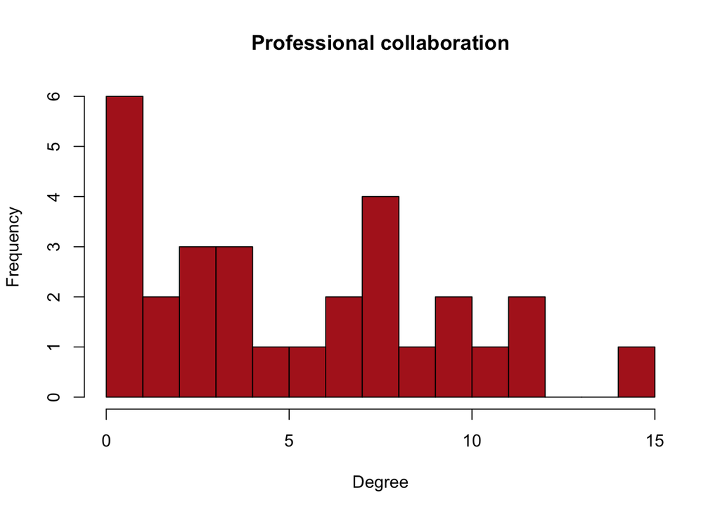

```r
hist(deg.col,
     col = "firebrick",
     xlab = "Degree",
     ylab = "Frequency",
     main = "Professional collaboration",
     breaks = 0:max(deg.col)
     )
```

## In- and out-degree (directed)

If the network is directed: * in-degree (*popularity*): number of arcs directed to a vertex * out-degree (*activity*): number of arcs directed away from a vertex

Let’s look at the support network

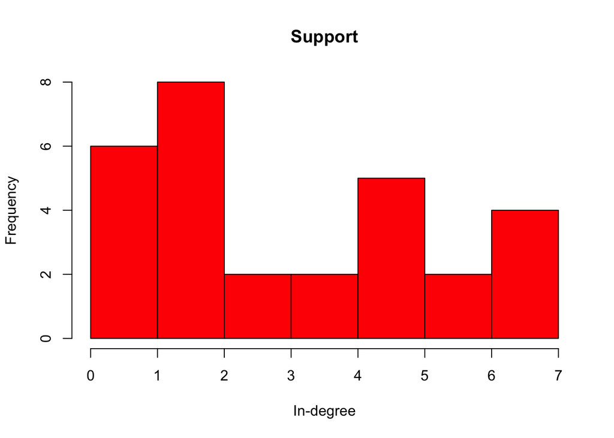

```r
sup.indeg <- degree(support, mode = "in")
hist(sup.indeg,
     col = "red",
     xlab = "In-degree",
     ylab = "Frequency",
     main = "Support",
     breaks = 0:max(sup.indeg)
     )
```

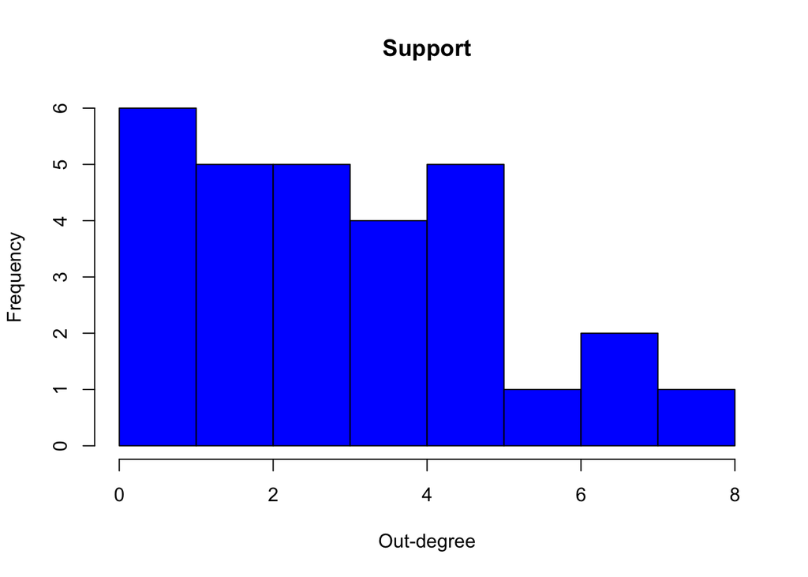

```r
sup.outdeg <- degree(support, mode = "out")
hist(sup.outdeg,
     col = "blue",
     xlab = "Out-degree",
     ylab = "Frequency",
     main = "Support",
     breaks = 0:max(sup.outdeg)
     )
```

Let’s plot both degree directions in the same chart: * We need `ggplot()`, which applies to `data.frames` or `tibbles` * Create a `tibble` with two columns (in- and out-degree) * In order to plot two variables in the same chart, we need to make it a tidy dataset: 1. Each variable must have its own column. 2. Each observation must have its own row. 3. Each value must have its own cell. * change dataset form to a longer form with degree in one variable and direction as the other variable  
* now we can apply `ggplot`

```r
library(tidyverse)
```

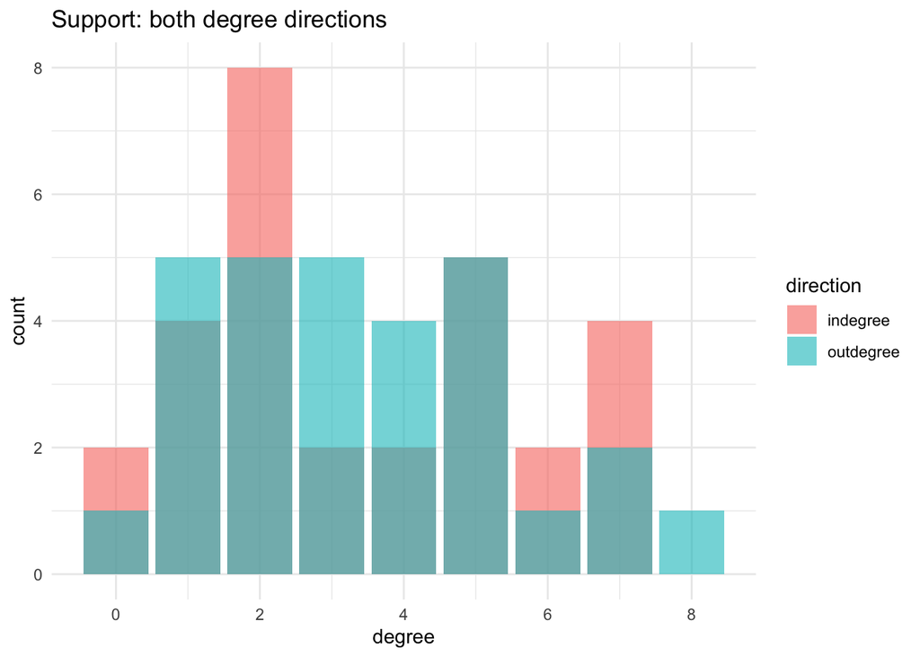

```r
df <- tibble(
  indegree = sup.indeg,
  outdegree = sup.outdeg
) %>%
  pivot_longer(
    cols = everything(),
    names_to = "direction",
    values_to = "degree"
  )

df %>%
  ggplot(aes(x = degree, fill = direction)) +
  geom_bar(position = "identity", alpha = .6) +
  theme_minimal() +
  ggtitle("Support: both degree directions")
```

Basic bivariate statistics can be applied

```r
cor.test(sup.indeg, sup.outdeg)
```

```
##
##  Pearson's product-moment correlation
##
## data:  sup.indeg and sup.outdeg
## t = 0.73036, df = 27, p-value = 0.4715
## alternative hypothesis: true correlation is not equal to 0
## 95 percent confidence interval:
##  -0.2395364  0.4811495
## sample estimates:
##       cor
## 0.1391889
```

# 5 Node attributes

- We might want to analyse whether different degree values are linked to the subjects’ individual properties.
- We need to analyse node attributes

First, we need to load data.

```r
attributes <- read_csv(file = here("data", "attr.csv"))
attributes
```

| X1 | id | edu | age | age3 | gender | seniority | seniority.rec | contract | field | family | children | employ | rev | motiv | gentrust | identity | soccap | satisf |
| --- | --- | --- | --- | --- | --- | --- | --- | --- | --- | --- | --- | --- | --- | --- | --- | --- | --- | --- |
| 1 | V1 | 0 | 40 | 2 | 1 | 17 | 1 | 1 | 0 | 0 | 0 | 1 | 0 | 4 | 5166666667 | 3666666667 | 2 | 5 |
| 2 | V2 | 1 | 41 | 2 | 1 | 46 | 3 | 1 | 3 | 3 | 0 | 2 | 3 | 3 | 5333333333 | 3666666667 | 2 | 4 |
| 3 | V3 | 2 | 25 | 0 | 0 | 39 | 3 | 1 | 9 | 0 | 0 | 2 | 1 | 5 | 1833333333 | 2 | NA | 4 |
| 4 | V4 | 2 | 28 | 0 | 1 | 25 | 2 | 1 | 4 | 1 | 0 | 0 | NA | NA | 4833333333 | 4333333333 | 2 | 3 |
| 5 | V5 | 2 | 28 | 0 | 1 | 7 | 0 | 1 | 6 | 1 | 0 | 1 | 0 | 6 | 25 | 3 | 0 | 3 |
| 6 | V6 | 2 | 31 | 1 | 1 | 43 | 3 | 1 | 6 | 3 | 0 | 2 | 4 | 0 | 4 | 4666666667 | 13 | 5 |
| 7 | V7 | 3 | 39 | 1 | 1 | 17 | 1 | 1 | 7 | 3 | 1 | 0 | NA | NA | 45 | 2666666667 | 0 | 4 |
| 8 | V8 | 2 | 28 | 0 | 1 | 46 | 3 | 0 | 10 | 2 | 0 | 2 | 2 | 4 | 2333333333 | 3333333333 | 7 | 3 |
| 9 | V9 | 1 | 31 | 1 | 1 | 28 | 2 | 1 | 1 | 0 | 0 | 2 | 4 | 3 | 5333333333 | 4 | 4 | 5 |
| 10 | V10 | 1 | 28 | 0 | 1 | 46 | 3 | 1 | 1 | 0 | 0 | 2 | 0 | 2 | 45 | 4 | 6 | 6 |

[output cut: 19 more lines]

Now we can integrate our dataset of the nodes’ attributes to the graph object.

```r
vertex_attr(support) <- vertex_attr(collaboration) <- attributes
```

- Node attributes can be inspected
- `V()` can be inspected as a `data.frame`

```r
V(collaboration)$gender
```

```
##  [1] 1 1 0 1 1 1 1 1 1 1 1 1 1 0 1 1 1 1 0 1 1 1 1 1 0 1 0 1 1
```

- Plot support w/ attributes
- Let’s try with a more powerful package, which exploits the power of `ggplot`

```r
library(ggraph)
```

Plot

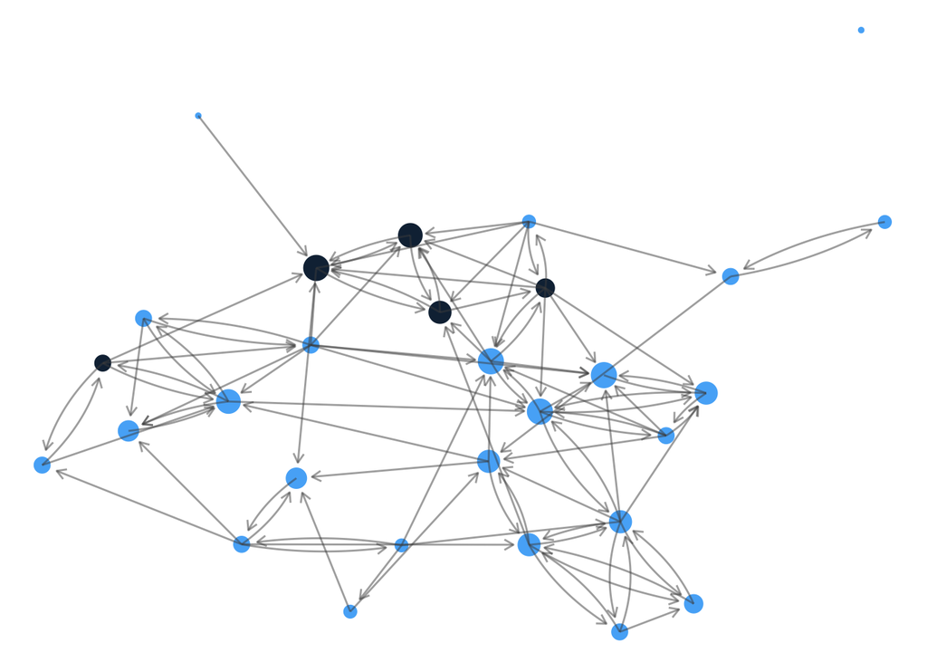

```r
support.plot <- support %>%
  ggraph(layout = "fr")
  # ggraph(layout = "auto")
  # ggraph(layout = "circle")
  # ggraph(layout = "kk")

support.plot +
  geom_node_point(
    aes(
      size = sup.indeg,
      color = gender
    ),
    show.legend = FALSE
  ) +
  # geom_edge_link() +
  geom_edge_fan(
    arrow = arrow(length = unit(2, "mm")),
    end_cap = circle(3, "mm"),
    color = "grey30",
    width = .5,
    alpha = .5
  ) +
  theme_void()
```

# 6 Centrality

- Which nodes are the most **important** ones?
- *Centrality* is a (rather vague) concept of (structural) importance within a network
- In a wider sense, a node’s degree can be seen as its *degree centrality*.

Plot collaboration network by emphasizing nodes’ degree centrality

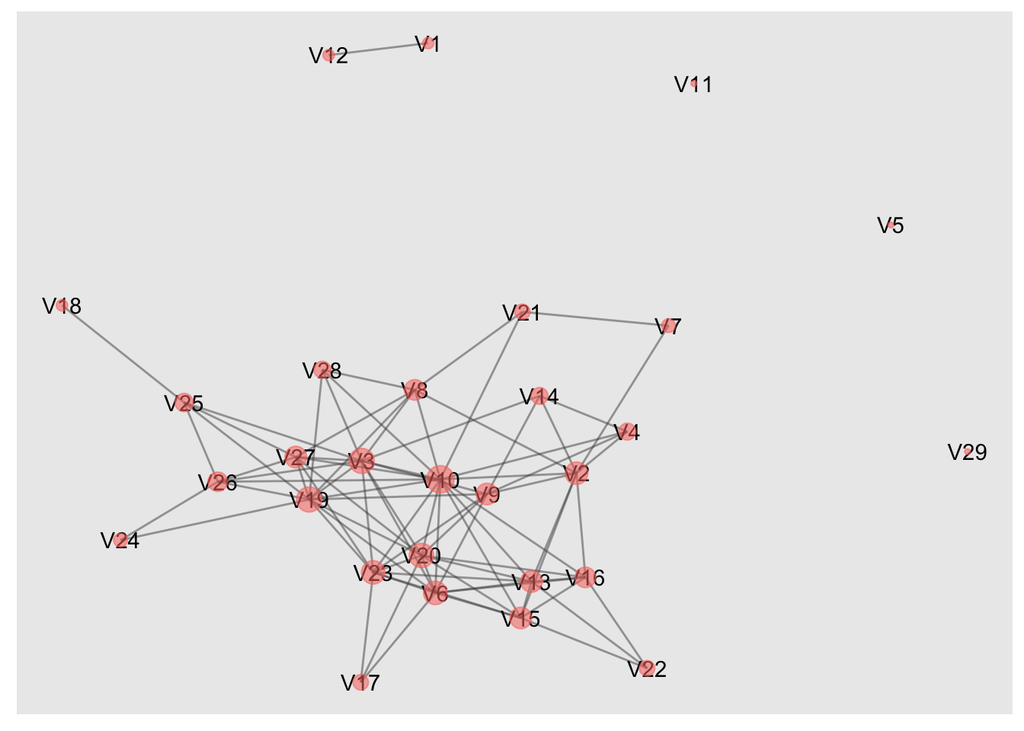

```r
collab.plot <- collaboration %>%
  ggraph(layout = "fr") +
  geom_edge_link(
    # arrow = arrow(length = unit(2, "mm")),
    # end_cap = circle(3, "mm"),
    color = "grey30",
    width = .5,
    alpha = .5
  ) +
  geom_node_text(aes(label = sup.nodes))

collab.plot +
  geom_node_point(
    aes(
      size = degree(collaboration),
      color = "red",
      alpha = .5
    ),
    show.legend = FALSE
  )
```

## 6.1 Eigenvector centrality

Example data

```r
net1 <- read_rds(here("data", "cent_example_1.rds"))
# net2 <- read_rds(here("data", "cent_example_2.rds"))
```

If we plot the network by visualizing degree centrality, who is the most central node?

```r
V(net1)$names <- 1:vcount(net1)

my.plot <- net1 %>%
  ggraph(layout = "auto") +
  geom_edge_link(
    color = "grey",
    width = .5
  ) +
  geom_node_text(aes(label = V(net1)$names))
```

```
## Using `stress` as default layout
```

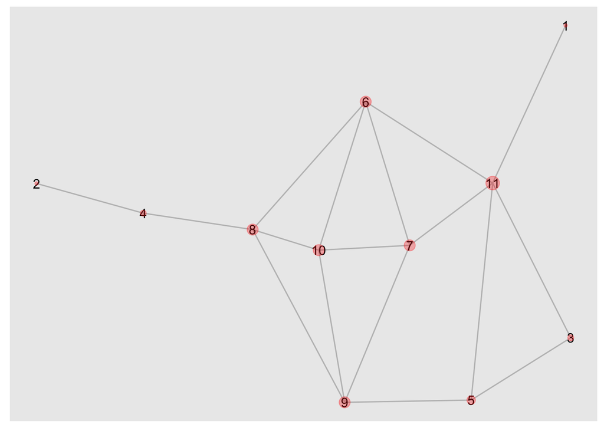

```r
my.plot +
  geom_node_point(
    size = degree(net1),
    color = "red",
    alpha = .3
  )
```

Who would you choose for a policy intervention to let something diffuse more rapidly?

We need to calculate *eigenvector centrality* (see slides)

```r
eigen_centrality(net1)
```

```
## $vector
##  [1] 0.2259630 0.0645825 0.3786244 0.2415182 0.5709057 0.9846544 1.0000000
##  [8] 0.8386195 0.9113529 0.9986474 0.8450304
##
## $value
## [1] 3.739685
##
## $options
## $options$bmat
## [1] "I"
##
## $options$n
## [1] 11
##
## $options$which
## [1] "LA"
##
## $options$nev
## [1] 1
##
## $options$tol
## [1] 0
##
## $options$ncv
## [1] 0
##
## $options$ldv
## [1] 0
##
## $options$ishift
## [1] 1
##
## $options$maxiter
## [1] 1000
##
## $options$nb
## [1] 1
##
## $options$mode
## [1] 1
```

[output cut: 12 more lines]

```
##
## $options$iter
## [1] 8
##
## $options$nconv
## [1] 1
##
## $options$numop
## [1] 26
##
## $options$numopb
## [1] 0
##
## $options$numreo
## [1] 11
```

- composite object
- we need to retrieve a vector
- scaled

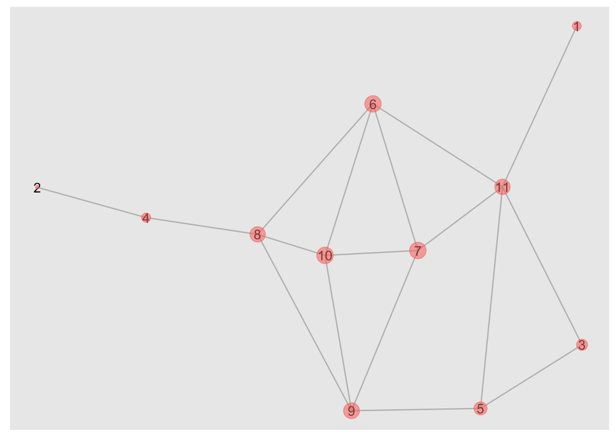

```r
my.plot +
  geom_node_point(
    aes(
      size = eigen_centrality(net1)$vector,
      color = "red",
      alpha = .5
    ),
    show.legend = FALSE
  )
```

Compare degree centrality and eigenvector centrality

```r
tibble(
  vertex = 1:vcount(net1),
  deg = degree(net1),
  eigen = eigen_centrality(net1)$vector
)
```

| vertex | deg | eigen |
| --- | --- | --- |
| 1 | 1 | 0.2259630 |
| 2 | 1 | 0.0645825 |
| 3 | 2 | 0.3786244 |
| 4 | 2 | 0.2415182 |
| 5 | 3 | 0.5709057 |
| 6 | 4 | 0.9846544 |
| 7 | 4 | 1.0000000 |
| 8 | 4 | 0.8386195 |
| 9 | 4 | 0.9113529 |
| 10 | 4 | 0.9986474 |

[output cut: 1 more lines]

```r
# %>%
#   arrange(desc(deg))
```

## 6.2 Betweenness centrality

Calculate

```r
btw.net <- betweenness(net1, normalized = TRUE)
btw.net
```

```
##  [1] 0.00000000 0.00000000 0.00000000 0.20000000 0.08518519 0.21851852
##  [7] 0.05925926 0.36296296 0.16296296 0.02962963 0.32592593
```

Plot

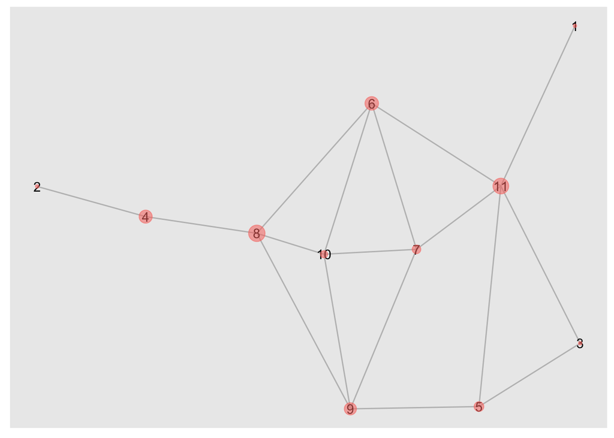

```r
my.plot +
  geom_node_point(
    aes(
      size = btw.net,
      color = "red",
      alpha = .5
    ),
    show.legend = FALSE
  )
```

Compare degree centrality, eigenvector centrality, and betweenness centrality

```r
tibble(
  vertex = 1:vcount(net1),
  deg = degree(net1),
  eigen = eigen_centrality(net1)$vector,
  btw = btw.net
)
```

| vertex | deg | eigen | btw |
| --- | --- | --- | --- |
| 1 | 1 | 0.2259630 | 0.00000000 |
| 2 | 1 | 0.0645825 | 0.00000000 |
| 3 | 2 | 0.3786244 | 0.00000000 |
| 4 | 2 | 0.2415182 | 0.20000000 |
| 5 | 3 | 0.5709057 | 0.08518519 |
| 6 | 4 | 0.9846544 | 0.21851852 |
| 7 | 4 | 1.0000000 | 0.05925926 |
| 8 | 4 | 0.8386195 | 0.36296296 |
| 9 | 4 | 0.9113529 | 0.16296296 |
| 10 | 4 | 0.9986474 | 0.02962963 |

[output cut: 1 more lines]

```r
# %>%
#   arrange(desc(deg))
```

## 6.3 Centrality in advice

Loading data

```r
advice <- graph_from_adjacency_matrix(as.matrix(read_tsv(here("data", "advice-coworking.txt"), col_names = F)))
advice
```

```
## IGRAPH bb870fe DN-- 29 120 --
## + attr: name (v/c)
## + edges from bb870fe (vertex names):
##  [1] X1 ->X2  X1 ->X12 X2 ->X4  X2 ->X8  X2 ->X13 X2 ->X15 X2 ->X16 X2 ->X28
##  [9] X3 ->X6  X3 ->X10 X3 ->X15 X3 ->X16 X3 ->X19 X3 ->X20 X3 ->X23 X3 ->X25
## [17] X3 ->X26 X4 ->X1  X4 ->X2  X4 ->X15 X4 ->X27 X4 ->X28 X5 ->X9  X5 ->X24
## [25] X6 ->X13 X6 ->X15 X6 ->X16 X6 ->X17 X6 ->X20 X6 ->X21 X6 ->X23 X7 ->X2
## [33] X8 ->X2  X8 ->X4  X8 ->X13 X8 ->X15 X8 ->X28 X9 ->X2  X9 ->X4  X9 ->X6
## [41] X9 ->X14 X9 ->X15 X9 ->X23 X10->X3  X10->X13 X10->X15 X10->X16 X10->X19
## [49] X10->X21 X10->X25 X11->X15 X12->X2  X12->X6  X12->X7  X13->X15 X13->X16
## [57] X14->X2  X14->X4  X14->X9  X14->X25 X15->X6  X15->X13 X15->X16 X15->X21
## + ... omitted several edges
```

Add attributes

```r
vertex_attr(advice) <- attributes
```

Plot degree centrality vs. betweenness centrality

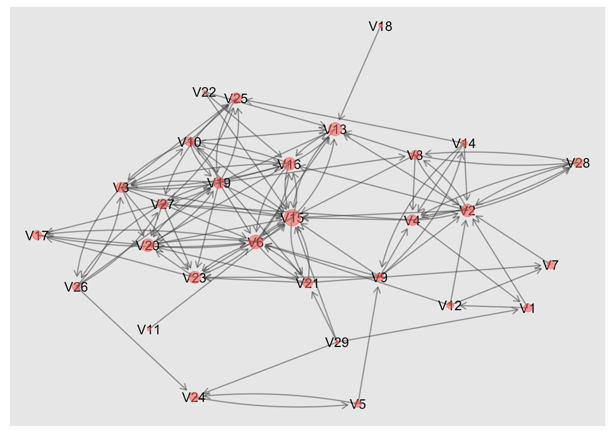

```r
advice.plot <- advice %>%
  ggraph(layout = "kk") +
  geom_edge_fan(
    arrow = arrow(length = unit(2, "mm")),
    end_cap = circle(3, "mm"),
    color = "grey30",
    width = .5,
    alpha = .5
  ) +
  geom_node_text(aes(label = sup.nodes))

advice.plot +
  geom_node_point(
    aes(
      size = degree(advice, mode = "in"),
      # size = betweenness(advice, directed = TRUE),
      color = "red",
      alpha = .5
    ),
    show.legend = FALSE
  )
```

# 7 Network processes

## 7.1 Reciprocity

Reciprocal ties in support network

Loading statnet

```r
library(statnet)
```

Creating a network object

```r
sup.net <- network(x = as_adjacency_matrix(support), attributes)
```

```
## <sparse>[ <logic> ] : .M.sub.i.logical() maybe inefficient
```

Another way:

```r
library(intergraph)
sup.net <- asNetwork(support)
```

Inspecting attributes and plotting

```r
sup.net %v% "age"
```

```
##  [1] 40 41 25 28 28 31 39 28 31 28 33 52 31 27 31 31 32 31 34 40 28 31 24 27 31
## [26] 24 34 27 36
```

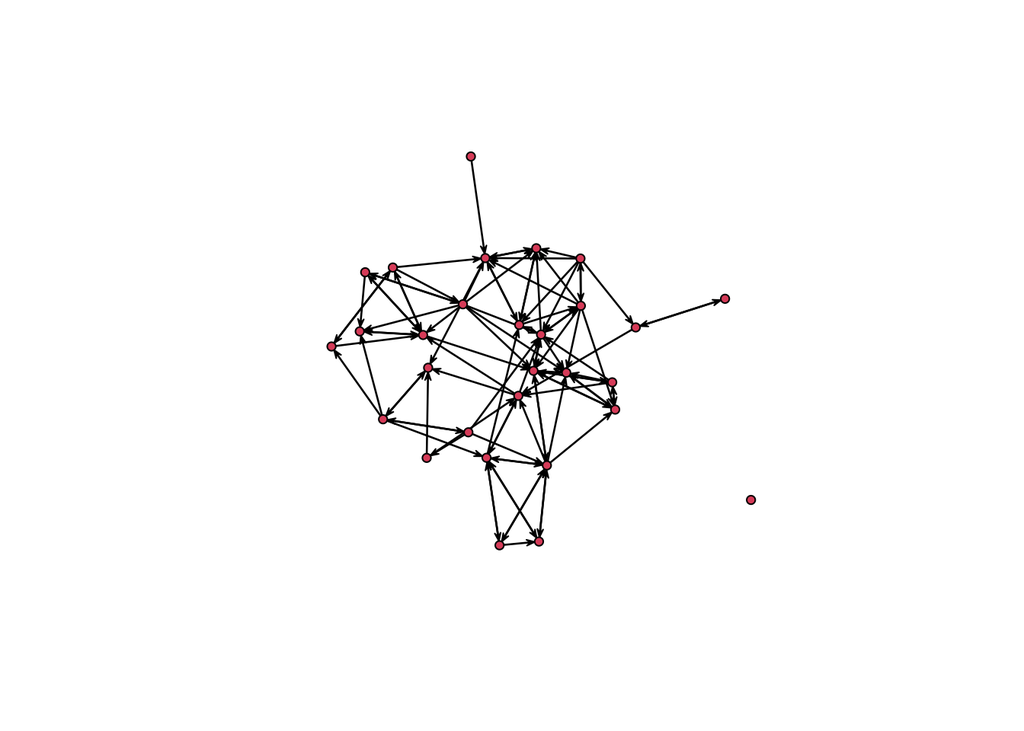

```r
plot(sup.net)
```

```
## Using `stress` as default layout
```

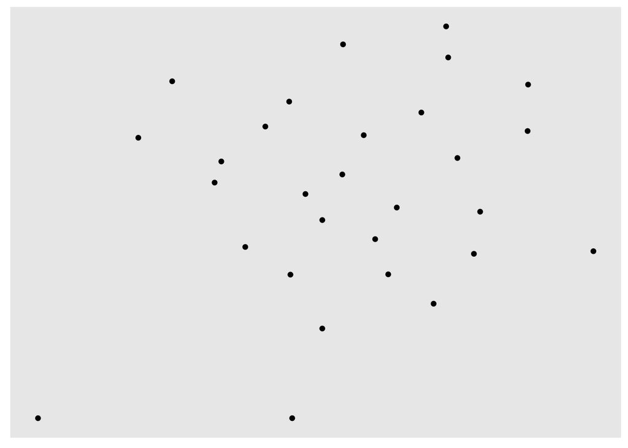

```r
sup.net %>% ggraph() + geom_node_point()
```

Reciprocal dyads

```r
mutuality(sup.net) # number of complete dyads (pairs with reciprocal ties)
```

```
## Mut
##  25
```

```r
sna::dyad.census(sup.net) # 812 dyads, 406 pairs of nodes (29 * 28 / 2), 99 dyads with at least one tie, of which 25 are symmetrical, which means 50 ties are in symmetric dyads + 49 which are not in symmetric dyads = 99 dyads with a tie
```

```
##      Mut Asym Null
## [1,]  25   49  332
```

What should we compare it to?

- fix number of nodes
- assume a data-generating process

Let’s compare it with a random network with 29 nodes. We need to specify a probability for ties to occur (let’s pick density)

```r
rnd.net <- rgraph(n = 29, m = 1, tprob = gden(sup.net))
gden(rnd.net)
```

```
## [1] 0.1317734
```

```r
mutuality(rnd.net)
```

```
## Mut
##   7
```

```r
sna::dyad.census(rnd.net)
```

```
##      Mut Asym Null
## [1,]   7   93  306
```

Let’s simulate a whole distribution of random graphs conditioned to n = 29 and probability = .12

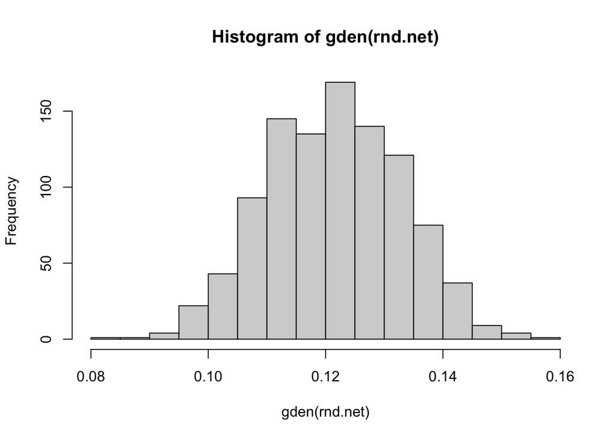

```r
rnd.net <- rgraph(n = 29, m = 1000, tprob = gden(sup.net))
hist(gden(rnd.net))
```

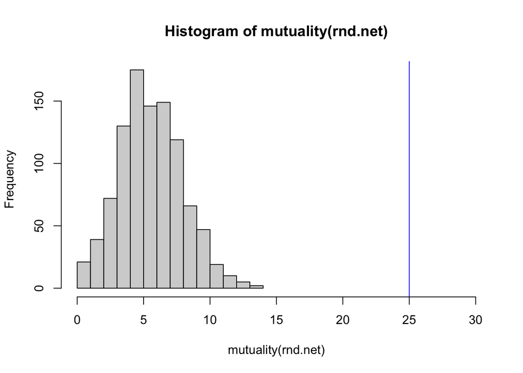

```r
hist(mutuality(rnd.net), xlim = c(0, 30))
abline(v = mutuality(sup.net), col="blue")
```

```r
sna::dyad.census(rnd.net)
```

```
##         Mut Asym Null
##    [1,]   2   85  319
##    [2,]   6   74  326
##    [3,]   6   78  322
##    [4,]   8   81  317
##    [5,]   5   87  314
##    [6,]   5   88  313
##    [7,]   8   83  315
##    [8,]   9   99  298
##    [9,]   6   76  324
##   [10,]   8   86  312
##   [11,]   5   90  311
##   [12,]   7   83  316
##   [13,]   3   83  320
##   [14,]   3   77  326
```

[output cut: 986 more lines]

- This was a Bernoulli distribution of graphs conditioned on the number of nodes
- Each tie has a homogeneous probability of realizing: **independence of observations**

Generate a U|L distribution of graphs conditioned on *n* and *L*

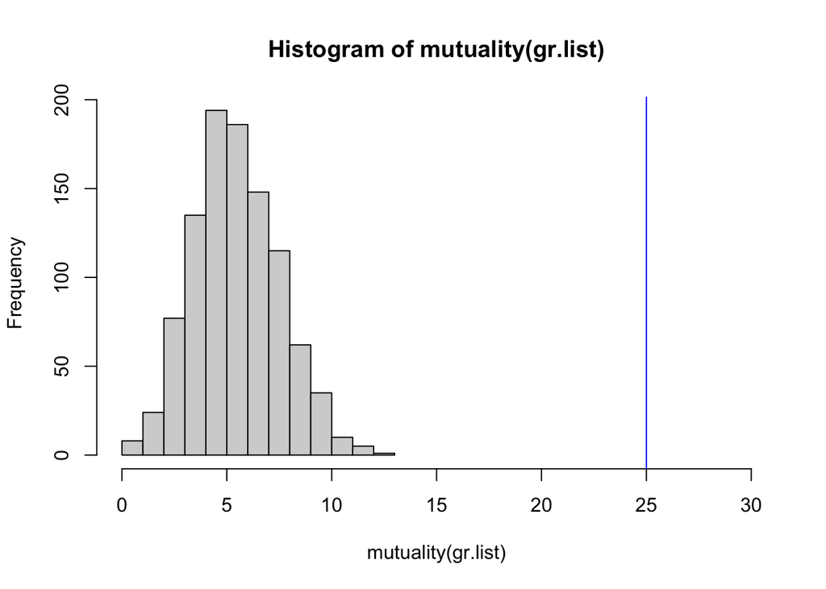

```r
gr.list <- list()
for (i in seq_len(1000)) {
  gr.list[[i]] <- sample_gnm(vcount(support), ecount(support), directed = TRUE)
}

gr.list <- map(gr.list, ~ asNetwork(.x))

hist(mutuality(gr.list), breaks = 15, xlim = c(0,30))
abline(v = mutuality(sup.net), col="blue")
```

Plot support

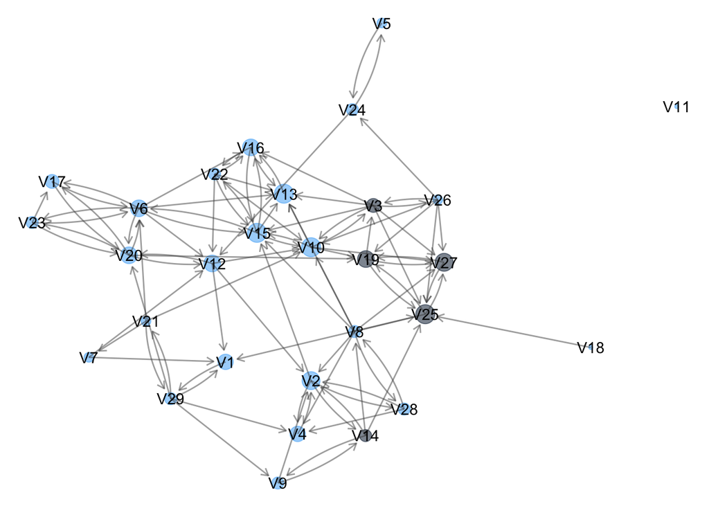

```r
support %>%
  ggraph(layout = "nicely") +
  geom_node_point(
    aes(
      size = sup.indeg,
      color = gender,
      alpha = .5
    ),
    show.legend = FALSE
  ) +
  # geom_edge_link() +
  geom_edge_fan(
    arrow = arrow(length = unit(2, "mm")),
    end_cap = circle(3, "mm"),
    color = "grey30",
    width = .5,
    alpha = .5
  ) +
  geom_node_text(aes(label = sup.nodes)) +
  theme_void()
```

# 8 ERGM

- Let’s start by estimating an ERGM by specifying the baseline probability of edges to be present as only parameter

We first specify the formula of the first model we’re going to estimate

```r
m0 <- sup.net ~ edges
m0
```

```
## sup.net ~ edges
```

Before fitting the model to our data, let’s look at the value of the count statistics in our network related to the terms specified in *m0*

```r
summary(m0)
```

```
## edges
##    99
```

```r
fit0 <- ergm(m0)
```

```
## Starting maximum pseudolikelihood estimation (MPLE):
```

```
## Evaluating the predictor and response matrix.
```

```
## Maximizing the pseudolikelihood.
```

```
## Finished MPLE.
```

```
## Stopping at the initial estimate.
```

```
## Evaluating log-likelihood at the estimate.
```

- Computation was very quick because we haven’t assumed any dependencies between the data!
- So, there is no need to use MCMC-MLE (Markov Chain Monte Carlo Maximum Likelihood Estimation)
- Maximum Pseudo-Likelihood Estimation (MPLE) was emplyed, wich doesn’t involve simulation
- (see slides for more details on estimation)

Let’s look at estimated coefficients and other relevant statistics

```r
summary(fit0)
```

```
## Call:
## ergm(formula = m0)
##
## Iterations:  5 out of 20
##
## Monte Carlo MLE Results:
##       Estimate Std. Error MCMC % z value Pr(>|z|)
## edges  -1.9744     0.1073      0  -18.41   <1e-04 ***
## ---
## Signif. codes:  0 '***' 0.001 '**' 0.01 '*' 0.05 '.' 0.1 ' ' 1
##
##      Null Deviance: 1125.7  on 812  degrees of freedom
##  Residual Deviance:  602.1  on 811  degrees of freedom
##
## AIC: 604.1    BIC: 608.8    (Smaller is better.)
```

We can infer a negative tendency of ties to form, compared to a graph distribution generated by assuming independency between dyads. Random chance is 0.5, so no surprise to find a negative tendency. It’s a **social** network, humans don’t just form random ties with every other human they meet!

Let’s retrieve the estimated coefficient values:

```r
coef(fit0)
```

```
##     edges
## -1.974362
```

- From these estimates we can infer that the log-odds — *ln(p/(i-p))* — of $x_{ij} = 1$ is equal to `coef(fit0)[1]` * the change-statistic ($\delta$) in the model term, so that changing the local status of $x_{ij}$ increases the global number of ties.
- In this case, the change-statistic values is 1 because each tie addition increases the count-statistic of the *edges* term by 1

From log-odds to odds-ratio:

```r
exp(coef(fit0)) / (1 + exp(coef(fit0)))
```

```
##     edges
## 0.1219212
```

It’s equal to the density of our network!

- What we estimated so far is a model that generates a Bernouilli distribution, similar to the one derived by an Erdös-Renyi model
- Now it’s time to test the effect of reciprocity in our network
- We do it by assuming dyadic dependency between the data (i.e., $Pr(x_{ij})$ depends on $Pr(x_{ji})$)
- Then we estimate the value of the $\theta$ parameter of a *reciprocity* term

Updating our model formula and checking count-statistics

```r
m1 <- update.formula(m0, . ~ . + mutual)
summary(m1)
```

```
##  edges mutual
##     99     25
```

```r
fit1 <- ergm(m1)
```

```
## Starting maximum pseudolikelihood estimation (MPLE):
```

```
## Evaluating the predictor and response matrix.
```

```
## Maximizing the pseudolikelihood.
```

```
## Finished MPLE.
```

```
## Starting Monte Carlo maximum likelihood estimation (MCMLE):
```

```
## Iteration 1 of at most 20:
```

```
## Optimizing with step length 1.
```

```
## The log-likelihood improved by 0.007731.
```

```
## Step length converged once. Increasing MCMC sample size.
```

```
## Iteration 2 of at most 20:
```

```
## Optimizing with step length 1.
```

```
## The log-likelihood improved by 0.0009685.
```

```
## Step length converged twice. Stopping.
```

```
## Finished MCMLE.
```

```
## Evaluating log-likelihood at the estimate. Using 20 bridges: 1 2 3 4 5 6 7 8 9 10 11 12 13 14 15 16 17 18 19 20 .
## This model was fit using MCMC.  To examine model diagnostics and check
## for degeneracy, use the mcmc.diagnostics() function.
```

It took longer than the first model. In this case, MPLE wasn’t powerful enough because we assumed *dyadic dependency* between our data, so MCMCMLE kicked in.

Let’s look at estimated coefficients:

```r
summary(fit1)
```

```
## Call:
## ergm(formula = m1)
##
## Iterations:  2 out of 20
##
## Monte Carlo MLE Results:
##        Estimate Std. Error MCMC % z value Pr(>|z|)
## edges   -2.6033     0.1526      0 -17.064   <1e-04 ***
## mutual   2.6187     0.3488      0   7.509   <1e-04 ***
## ---
## Signif. codes:  0 '***' 0.001 '**' 0.01 '*' 0.05 '.' 0.1 ' ' 1
##
##      Null Deviance: 1125.7  on 812  degrees of freedom
##  Residual Deviance:  548.1  on 810  degrees of freedom
##
## AIC: 552.1    BIC: 561.5    (Smaller is better.)
```

- From this model, we can infer that `sup.net` is composed by a higher number of reciprocated dyads than random networks with .12 density
- We can infer it from the positive value of the estimated coefficient of *mutual* and the fact that the estimated standard error (S.E.) is less than twice the size of the parameter effect
- However, the large amount of reciprocated dyads might be due to other network processes generating an arc such that $x_{ij} = 1$ where $x_{ji} = 1$
- Let’s check transitive closure (see slides), by adding *geometrically weighted edgewise partners*

We’ll start by defining an easily-interpretable fixed decay value of *gwesp*

```r
m2 <- update.formula(m1, . ~ . + gwesp(.5, fixed = T))
summary(m2)
```

```
##           edges          mutual gwesp.fixed.0.5
##        99.00000        25.00000        81.46703
```

```r
m3 <- update.formula(m2, . ~ . + twopath)
summary(m3)
```

```
##           edges          mutual gwesp.fixed.0.5         twopath
##        99.00000        25.00000        81.46703       306.00000
```

Estimating coefficients of the new model

```r
fit3 <- ergm(m3)
```

```
## Starting maximum pseudolikelihood estimation (MPLE):
```

```
## Evaluating the predictor and response matrix.
```

```
## Maximizing the pseudolikelihood.
```

```
## Finished MPLE.
```

```
## Starting Monte Carlo maximum likelihood estimation (MCMLE):
```

```
## Iteration 1 of at most 20:
```

```
## Optimizing with step length 1.
```

```
## The log-likelihood improved by 0.7757.
```

```
## Step length converged once. Increasing MCMC sample size.
```

```
## Iteration 2 of at most 20:
```

```
## Optimizing with step length 1.
```

```
## The log-likelihood improved by 0.009442.
```

```
## Step length converged twice. Stopping.
```

```
## Finished MCMLE.
```

```
## Evaluating log-likelihood at the estimate. Using 20 bridges: 1 2 3 4 5 6 7 8 9 10 11 12 13 14 15 16 17 18 19 20 .
## This model was fit using MCMC.  To examine model diagnostics and check
## for degeneracy, use the mcmc.diagnostics() function.
```

```r
summary(fit3)
```

```
## Call:
## ergm(formula = m3)
##
## Iterations:  2 out of 20
##
## Monte Carlo MLE Results:
##                 Estimate Std. Error MCMC % z value Pr(>|z|)
## edges           -2.26782    0.34847      0  -6.508   <1e-04 ***
## mutual           1.99764    0.35049      0   5.700   <1e-04 ***
## gwesp.fixed.0.5  1.06837    0.15799      0   6.762   <1e-04 ***
## twopath         -0.23780    0.05677      0  -4.189   <1e-04 ***
## ---
## Signif. codes:  0 '***' 0.001 '**' 0.01 '*' 0.05 '.' 0.1 ' ' 1
##
##      Null Deviance: 1125.7  on 812  degrees of freedom
##  Residual Deviance:  494.5  on 808  degrees of freedom
##
## AIC: 502.5    BIC: 521.3    (Smaller is better.)
```

# References

Bianchi, Federico, Niccolò Casnici, and Flaminio Squazzoni. 2018. “Solidarity as a Byproduct of Professional Collaboration: Social Support and Trust in a Coworking Space.” *Social Networks* 54: 61–72. https://doi.org/10.1016/j.socnet.2017.12.002.